# HW 03 - Modelling

Your Name (S000000)

2026-11-18

## Data load and preparation before modelling

```r
gss16 <- read.csv("data/gss16.csv")

gss16_advfront <- gss16 %>%
  select(advfront, emailhr, educ, polviews, wrkstat) %>%
  drop_na() %>%
  mutate(
    advfront = case_when(
      advfront == "Strongly agree" ~ "Agree",
      advfront == "Agree" ~ "Agree",
      TRUE ~ "Not agree"
    ),
    advfront = factor(advfront) %>% fct_relevel("Not agree", "Agree"),
    polviews = case_when(
      str_detect(polviews, "[Cc]onservative") ~ "Conservative",
      str_detect(polviews, "[Ll]iberal") ~ "Liberal",
      TRUE ~ polviews
    ),
    polviews = factor(polviews) %>% fct_relevel("Conservative", "Moderate", "Liberal"),
    wrkstat = factor(wrkstat)
  )
glimpse(gss16_advfront)
```

```
## Rows: 1,172
## Columns: 5
## $ advfront <fct> Agree, Not agree, Not agree, Agree, Agree, Agree, Agree, Agre…
## $ emailhr  <int> 12, 0, 0, 2, 40, 10, 0, 1, 2, 25, 0, 1, 2, 0, 0, 2, 1, 7, 60,…
## $ educ     <int> 16, 12, 12, 14, 14, 12, 10, 10, 13, 12, 18, 12, 12, 12, 12, 1…
## $ polviews <fct> Moderate, Liberal, Moderate, Liberal, Liberal, Liberal, Moder…
## $ wrkstat  <fct> "Working fulltime", "Working fulltime", "Working parttime", "…
```

## Exercise 1: Create a linear regression model

### a) Fit and interpret the simple linear regression

```r
model_1 <- lm(emailhr ~ educ, data = gss16_advfront)
summary(model_1)
```

```
##
## Call:
## lm(formula = emailhr ~ educ, data = gss16_advfront)
##
## Residuals:
##     Min      1Q  Median      3Q     Max
## -10.951  -5.838  -4.097   1.532  83.162
##
## Coefficients:
##             Estimate Std. Error t value Pr(>|t|)
## (Intercept)  -2.7573     1.6600  -1.661    0.097 .
## educ          0.6854     0.1157   5.924 4.13e-09 ***
## ---
## Signif. codes:  0 '***' 0.001 '**' 0.01 '*' 0.05 '.' 0.1 ' ' 1
##
## Residual standard error: 10.86 on 1170 degrees of freedom
## Multiple R-squared:  0.02912,    Adjusted R-squared:  0.02829
## F-statistic: 35.09 on 1 and 1170 DF,  p-value: 4.131e-09
```

```r
broom::tidy(model_1, conf.int = TRUE)
```

```
## # A tibble: 2 × 7
##   term        estimate std.error statistic       p.value conf.low conf.high
##   <chr>          <dbl>     <dbl>     <dbl>         <dbl>    <dbl>     <dbl>
## 1 (Intercept)   -2.76      1.66      -1.66 0.0970          -6.01      0.500
## 2 educ           0.685     0.116      5.92 0.00000000413    0.458     0.912
```

```r
broom::glance(model_1)
```

```
## # A tibble: 1 × 12
##   r.squared adj.r.squared sigma statistic       p.value    df logLik   AIC   BIC
##       <dbl>         <dbl> <dbl>     <dbl>         <dbl> <dbl>  <dbl> <dbl> <dbl>
## 1    0.0291        0.0283  10.9      35.1 0.00000000413     1 -4458. 8922. 8937.
## # ℹ 3 more variables: deviance <dbl>, df.residual <int>, nobs <int>
```

The fitted line is **emailhr = -2.76 + 0.69 × educ**. The slope means that each additional year of education is associated with an estimated 0.69-hour change in weekly email time on average. This is an association, not a causal effect.

### b) Model performance and assumptions

```r
g1 <- broom::glance(model_1)
rmse_1 <- sqrt(mean(residuals(model_1)^2))
model_1_metrics <- tibble(R_squared = g1$r.squared, Adjusted_R_squared = g1$adj.r.squared, RMSE = rmse_1)
model_1_metrics
```

```
## # A tibble: 1 × 3
##   R_squared Adjusted_R_squared  RMSE
##       <dbl>              <dbl> <dbl>
## 1    0.0291             0.0283  10.9
```

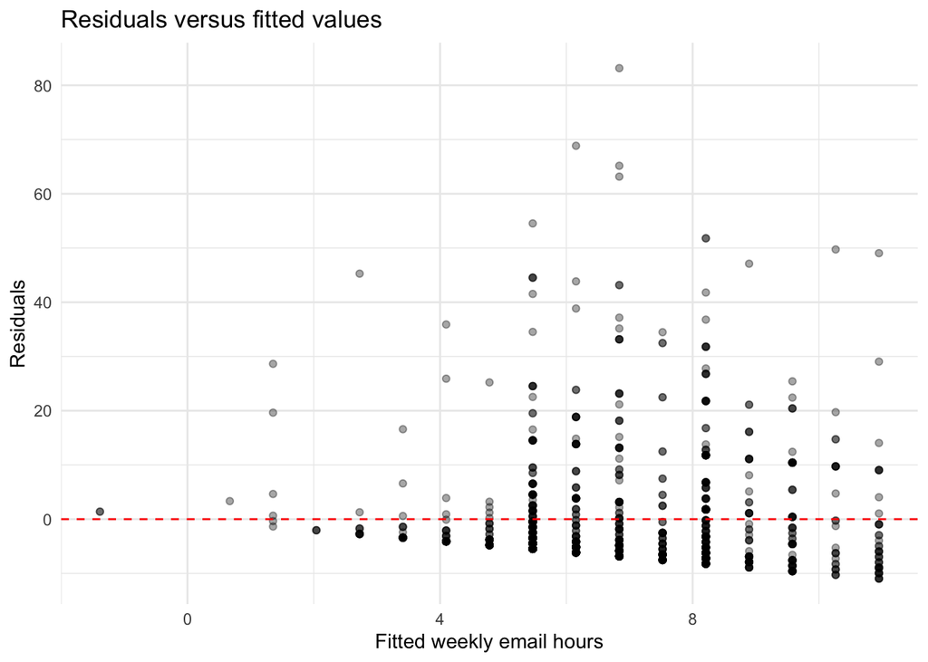

```r
aug_1 <- broom::augment(model_1)
ggplot(aug_1, aes(.fitted, .resid)) +
  geom_point(alpha = 0.35) + geom_hline(yintercept = 0, linetype = 2, colour = "red") +
  labs(x = "Fitted weekly email hours", y = "Residuals", title = "Residuals versus fitted values") +
  theme_minimal()
```

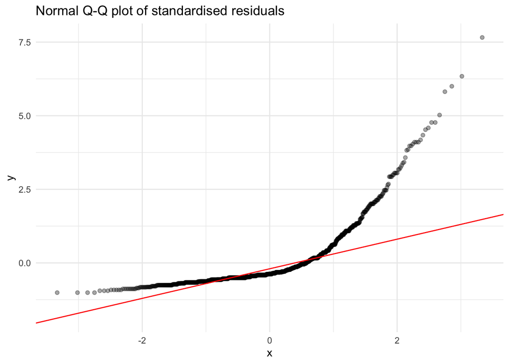

```r
ggplot(aug_1, aes(sample = .std.resid)) +
  stat_qq(alpha = 0.35) + stat_qq_line(colour = "red") +
  labs(title = "Normal Q-Q plot of standardised residuals") + theme_minimal()
```

R-squared is 0.029 and RMSE is 10.86 hours; R-squared is the fraction of sample variation explained, while RMSE gives a typical residual scale in hours. Use the residual plots to assess assumptions: a roughly pattern-free residual cloud with similar spread supports linearity and constant variance, and points near the Q-Q line support approximately normal errors. Email hours are often skewed and may contain extreme values, so departures in the plots and the modest explanatory power mean this simple model should be treated as a rough summary rather than a precise predictor.

## Exercise 2: Compare two linear models

```r
model_2 <- lm(emailhr ~ educ + advfront, data = gss16_advfront)
broom::tidy(model_2, conf.int = TRUE)
```

```
## # A tibble: 3 × 7
##   term          estimate std.error statistic       p.value conf.low conf.high
##   <chr>            <dbl>     <dbl>     <dbl>         <dbl>    <dbl>     <dbl>
## 1 (Intercept)     -3.06      1.76     -1.74  0.0820          -6.51      0.389
## 2 educ             0.678     0.117     5.80  0.00000000830    0.449     0.907
## 3 advfrontAgree    0.481     0.918     0.524 0.601           -1.32      2.28
```

```r
broom::glance(model_2)
```

```
## # A tibble: 1 × 12
##   r.squared adj.r.squared sigma statistic      p.value    df logLik   AIC   BIC
##       <dbl>         <dbl> <dbl>     <dbl>        <dbl> <dbl>  <dbl> <dbl> <dbl>
## 1    0.0293        0.0277  10.9      17.7 0.0000000275     2 -4458. 8923. 8944.
## # ℹ 3 more variables: deviance <dbl>, df.residual <int>, nobs <int>
```

```r
comparison <- tibble(
  Model = c("educ only", "educ + advfront"),
  R_squared = c(broom::glance(model_1)$r.squared, broom::glance(model_2)$r.squared),
  Adjusted_R_squared = c(broom::glance(model_1)$adj.r.squared, broom::glance(model_2)$adj.r.squared),
  RMSE = c(sqrt(mean(residuals(model_1)^2)), sqrt(mean(residuals(model_2)^2))),
  AIC = c(AIC(model_1), AIC(model_2))
)
comparison
```

```
## # A tibble: 2 × 5
##   Model           R_squared Adjusted_R_squared  RMSE   AIC
##   <chr>               <dbl>              <dbl> <dbl> <dbl>
## 1 educ only          0.0291             0.0283  10.9 8922.
## 2 educ + advfront    0.0293             0.0277  10.9 8923.
```

In the second model, the 0.48 coefficient for **Agree** is the adjusted difference in predicted weekly email hours between respondents who agree and those who do not, at the same education level. The reference group is Not agree. Compare models on the same data: higher adjusted R-squared and lower RMSE/AIC indicate better in-sample fit (AIC also penalises extra parameters). Here, the model with advfront has a lower RMSE; any improvement is an association and need not be practically large.

## Exercise 3: Create a workflow to fit a model to the training data

```r
set.seed(1234)
gss16_split <- initial_split(gss16_advfront, prop = 0.75, strata = advfront)
gss16_train <- training(gss16_split)
gss16_test <- testing(gss16_split)
table(gss16_train$advfront)
```

```
##
## Not agree     Agree
##       124       754
```

```r
table(gss16_test$advfront)
```

```
##
## Not agree     Agree
##        42       252
```

### a) Recipe, model and workflow

The outcome has two categories, so logistic regression is appropriate: it models the probability of agreement and returns probabilities between zero and one. Education is numeric, so it can enter the model directly.

```r
gss16_rec_1 <- recipe(advfront ~ educ, data = gss16_train)
gss16_mod_1 <- logistic_reg() %>% set_engine("glm") %>% set_mode("classification")
gss16_wflow_1 <- workflow() %>% add_recipe(gss16_rec_1) %>% add_model(gss16_mod_1)
gss16_fit_1 <- fit(gss16_wflow_1, data = gss16_train)
gss16_pred_1 <- predict(gss16_fit_1, new_data = gss16_test, type = "prob") %>%
  bind_cols(gss16_test %>% select(advfront))
head(gss16_pred_1)
```

```
## # A tibble: 6 × 3
##   `.pred_Not agree` .pred_Agree advfront
##               <dbl>       <dbl> <fct>
## 1            0.164        0.836 Not agree
## 2            0.192        0.808 Agree
## 3            0.164        0.836 Agree
## 4            0.0993       0.901 Agree
## 5            0.118        0.882 Agree
## 6            0.118        0.882 Agree
```

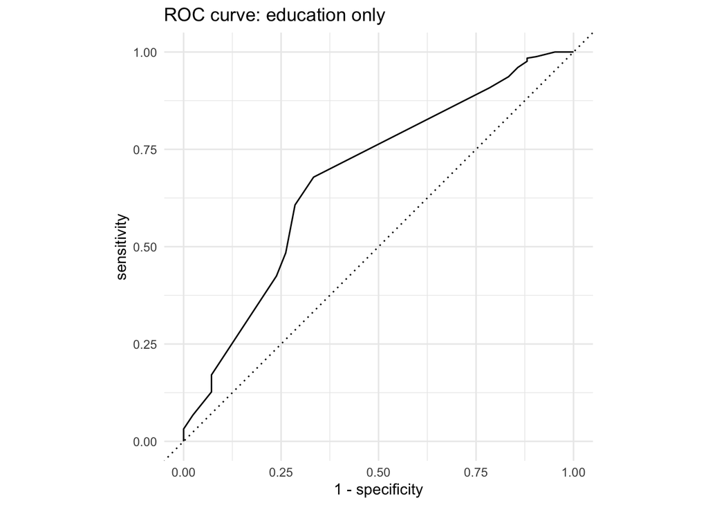

```r
roc_1 <- roc_curve(gss16_pred_1, truth = advfront, .pred_Agree, event_level = "second")
autoplot(roc_1) + labs(title = "ROC curve: education only") + theme_minimal()
```

## Exercise 4: Performance of a logistic regression

### a) Confusion matrix, sensitivity and specificity at 0.83

```r
cutoff <- 0.83
pred_class_1 <- factor(if_else(gss16_pred_1$.pred_Agree >= cutoff, "Agree", "Not agree"),
                        levels = levels(gss16_test$advfront))
confusion_1 <- table(Predicted = pred_class_1, Actual = gss16_test$advfront)
confusion_1
```

```
##            Actual
## Predicted   Not agree Agree
##   Not agree         9    23
##   Agree            33   229
```

```r
tn <- confusion_1["Not agree", "Not agree"]
fp <- confusion_1["Agree", "Not agree"]
fn <- confusion_1["Not agree", "Agree"]
tp <- confusion_1["Agree", "Agree"]
confusion_counts <- tibble(Measure = c("True positives", "True negatives", "False positives", "False negatives"), Count = c(tp, tn, fp, fn))
confusion_counts
```

```
## # A tibble: 4 × 2
##   Measure         Count
##   <chr>           <int>
## 1 True positives    229
## 2 True negatives      9
## 3 False positives    33
## 4 False negatives    23
```

```r
sensitivity_1 <- tp / (tp + fn)
specificity_1 <- tn / (tn + fp)
tibble(Sensitivity = sensitivity_1, Specificity = specificity_1)
```

```
## # A tibble: 1 × 2
##   Sensitivity Specificity
##         <dbl>       <dbl>
## 1       0.909       0.214
```

Sensitivity is the proportion of actual Agree responses identified as Agree; specificity is the proportion of actual Not agree responses identified as Not agree. The chosen high threshold can reduce false positives while missing more true positives.

### b) Expanded logistic regression workflow

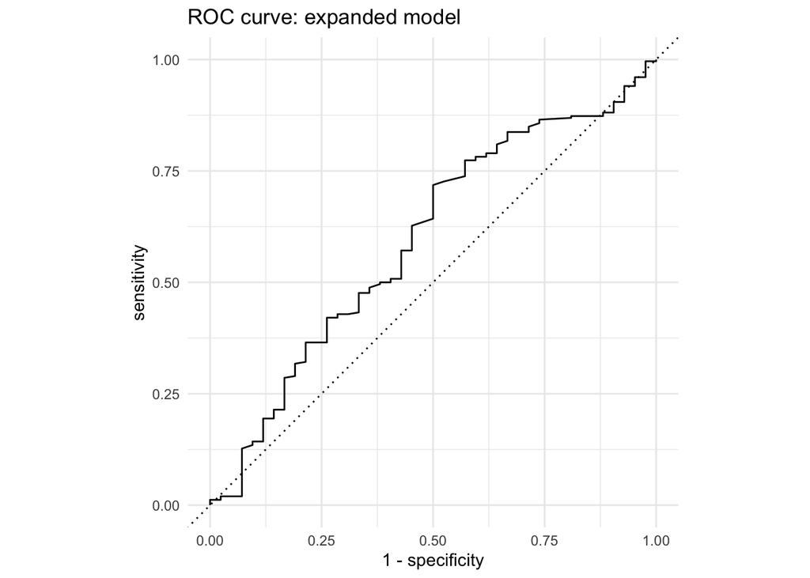

```r
gss16_rec_2 <- recipe(advfront ~ polviews + wrkstat + emailhr + educ, data = gss16_train) %>%
  step_dummy(all_nominal_predictors())
gss16_mod_2 <- logistic_reg() %>% set_engine("glm") %>% set_mode("classification")
gss16_wflow_2 <- workflow() %>% add_recipe(gss16_rec_2) %>% add_model(gss16_mod_2)
gss16_fit_2 <- fit(gss16_wflow_2, data = gss16_train)
gss16_pred_2 <- predict(gss16_fit_2, new_data = gss16_test, type = "prob") %>%
  bind_cols(gss16_test %>% select(advfront))
roc_2 <- roc_curve(gss16_pred_2, truth = advfront, .pred_Agree, event_level = "second")
autoplot(roc_2) + labs(title = "ROC curve: expanded model") + theme_minimal()
```

```r
auc_1 <- roc_auc(gss16_pred_1, truth = advfront, .pred_Agree, event_level = "second")$.estimate
auc_2 <- roc_auc(gss16_pred_2, truth = advfront, .pred_Agree, event_level = "second")$.estimate
tibble(Model = c("Education only", "Expanded predictors"), AUC = c(auc_1, auc_2))
```

```
## # A tibble: 2 × 2
##   Model                 AUC
##   <chr>               <dbl>
## 1 Education only      0.677
## 2 Expanded predictors 0.594
```

AUC summarises discrimination across all possible cutoffs; 0.5 is chance ranking and 1 is perfect ranking. Model 1 has higher test AUC (0.677 versus 0.594), so it performs better by this metric on this test split. The difference is descriptive and may vary across splits; the held-out test set gives a more honest comparison than training performance.